# Risk Factor Analysis

## Outcome Variable

**Outcome Variable:** stunted

## Predictor Variables

**Intervention Variable:** fage

**Adjustment Set:**

unadjusted

## Stratifying Variables

The analysis was stratified on these variable(s):

- agecat
- studyid
- country

## Data Summary

| agecat | studyid | country | A | n | nA | nAY0 | nAY1 |
| --- | --- | --- | --- | --- | --- | --- | --- |
| Birth | ki0047075b-MAL-ED | BANGLADESH | >=35 | 145 | 99 | 83 | 16 |
| Birth | ki0047075b-MAL-ED | BANGLADESH | <25 | 145 | 0 | 0 | 0 |
| Birth | ki0047075b-MAL-ED | BANGLADESH | [25-30) | 145 | 13 | 11 | 2 |
| Birth | ki0047075b-MAL-ED | BANGLADESH | [30-35) | 145 | 33 | 31 | 2 |
| Birth | ki0047075b-MAL-ED | BRAZIL | >=35 | 68 | 35 | 31 | 4 |
| Birth | ki0047075b-MAL-ED | BRAZIL | <25 | 68 | 3 | 3 | 0 |
| Birth | ki0047075b-MAL-ED | BRAZIL | [25-30) | 68 | 7 | 7 | 0 |
| Birth | ki0047075b-MAL-ED | BRAZIL | [30-35) | 68 | 23 | 20 | 3 |
| Birth | ki0047075b-MAL-ED | INDIA | >=35 | 131 | 57 | 49 | 8 |
| Birth | ki0047075b-MAL-ED | INDIA | <25 | 131 | 2 | 2 | 0 |
| Birth | ki0047075b-MAL-ED | INDIA | [25-30) | 131 | 24 | 20 | 4 |
| Birth | ki0047075b-MAL-ED | INDIA | [30-35) | 131 | 48 | 40 | 8 |
| Birth | ki0047075b-MAL-ED | NEPAL | >=35 | 61 | 31 | 28 | 3 |
| Birth | ki0047075b-MAL-ED | NEPAL | <25 | 61 | 0 | 0 | 0 |
| Birth | ki0047075b-MAL-ED | NEPAL | [25-30) | 61 | 6 | 6 | 0 |
| Birth | ki0047075b-MAL-ED | NEPAL | [30-35) | 61 | 24 | 22 | 2 |
| Birth | ki0047075b-MAL-ED | PERU | >=35 | 80 | 42 | 40 | 2 |
| Birth | ki0047075b-MAL-ED | PERU | <25 | 80 | 4 | 3 | 1 |
| Birth | ki0047075b-MAL-ED | PERU | [25-30) | 80 | 17 | 15 | 2 |
| Birth | ki0047075b-MAL-ED | PERU | [30-35) | 80 | 17 | 12 | 5 |
| Birth | ki0047075b-MAL-ED | SOUTH AFRICA | >=35 | 76 | 63 | 56 | 7 |
| Birth | ki0047075b-MAL-ED | SOUTH AFRICA | <25 | 76 | 1 | 1 | 0 |
| Birth | ki0047075b-MAL-ED | SOUTH AFRICA | [25-30) | 76 | 5 | 4 | 1 |
| Birth | ki0047075b-MAL-ED | SOUTH AFRICA | [30-35) | 76 | 7 | 6 | 1 |
| Birth | ki0047075b-MAL-ED | TANZANIA, UNITED REPUBLIC OF | >=35 | 46 | 27 | 24 | 3 |
| Birth | ki0047075b-MAL-ED | TANZANIA, UNITED REPUBLIC OF | <25 | 46 | 1 | 1 | 0 |
| Birth | ki0047075b-MAL-ED | TANZANIA, UNITED REPUBLIC OF | [25-30) | 46 | 3 | 3 | 0 |
| Birth | ki0047075b-MAL-ED | TANZANIA, UNITED REPUBLIC OF | [30-35) | 46 | 15 | 13 | 2 |
| Birth | ki1000304b-SAS-CompFeed | INDIA | >=35 | 70 | 5 | 4 | 1 |
| Birth | ki1000304b-SAS-CompFeed | INDIA | <25 | 70 | 23 | 14 | 9 |

[output cut: 314 more lines]

The following strata were considered:

- agecat: 12 months, studyid: ki0047075b-MAL-ED, country: BANGLADESH
- agecat: 12 months, studyid: ki0047075b-MAL-ED, country: BRAZIL
- agecat: 12 months, studyid: ki0047075b-MAL-ED, country: INDIA
- agecat: 12 months, studyid: ki0047075b-MAL-ED, country: NEPAL
- agecat: 12 months, studyid: ki0047075b-MAL-ED, country: PERU
- agecat: 12 months, studyid: ki0047075b-MAL-ED, country: SOUTH AFRICA
- agecat: 12 months, studyid: ki0047075b-MAL-ED, country: TANZANIA, UNITED REPUBLIC OF
- agecat: 12 months, studyid: ki1000304b-SAS-CompFeed, country: INDIA
- agecat: 12 months, studyid: ki1000304b-SAS-FoodSuppl, country: INDIA
- agecat: 12 months, studyid: ki1119695-PROBIT, country: BELARUS
- agecat: 12 months, studyid: ki1135781-COHORTS, country: GUATEMALA
- agecat: 12 months, studyid: ki1135781-COHORTS, country: PHILIPPINES
- agecat: 12 months, studyid: ki1148112-LCNI-5, country: MALAWI
- agecat: 18 months, studyid: ki0047075b-MAL-ED, country: BANGLADESH
- agecat: 18 months, studyid: ki0047075b-MAL-ED, country: BRAZIL
- agecat: 18 months, studyid: ki0047075b-MAL-ED, country: INDIA
- agecat: 18 months, studyid: ki0047075b-MAL-ED, country: NEPAL
- agecat: 18 months, studyid: ki0047075b-MAL-ED, country: PERU
- agecat: 18 months, studyid: ki0047075b-MAL-ED, country: SOUTH AFRICA
- agecat: 18 months, studyid: ki0047075b-MAL-ED, country: TANZANIA, UNITED REPUBLIC OF
- agecat: 18 months, studyid: ki1000304b-SAS-CompFeed, country: INDIA
- agecat: 18 months, studyid: ki1000304b-SAS-FoodSuppl, country: INDIA
- agecat: 18 months, studyid: ki1119695-PROBIT, country: BELARUS
- agecat: 18 months, studyid: ki1135781-COHORTS, country: GUATEMALA
- agecat: 18 months, studyid: ki1135781-COHORTS, country: PHILIPPINES
- agecat: 18 months, studyid: ki1148112-LCNI-5, country: MALAWI
- agecat: 24 months, studyid: ki0047075b-MAL-ED, country: BANGLADESH
- agecat: 24 months, studyid: ki0047075b-MAL-ED, country: BRAZIL
- agecat: 24 months, studyid: ki0047075b-MAL-ED, country: INDIA
- agecat: 24 months, studyid: ki0047075b-MAL-ED, country: NEPAL
- agecat: 24 months, studyid: ki0047075b-MAL-ED, country: PERU
- agecat: 24 months, studyid: ki0047075b-MAL-ED, country: SOUTH AFRICA
- agecat: 24 months, studyid: ki0047075b-MAL-ED, country: TANZANIA, UNITED REPUBLIC OF
- agecat: 24 months, studyid: ki1119695-PROBIT, country: BELARUS
- agecat: 24 months, studyid: ki1135781-COHORTS, country: GUATEMALA
- agecat: 24 months, studyid: ki1135781-COHORTS, country: PHILIPPINES
- agecat: 24 months, studyid: ki1148112-LCNI-5, country: MALAWI
- agecat: 3 months, studyid: ki0047075b-MAL-ED, country: BANGLADESH
- agecat: 3 months, studyid: ki0047075b-MAL-ED, country: BRAZIL
- agecat: 3 months, studyid: ki0047075b-MAL-ED, country: INDIA
- agecat: 3 months, studyid: ki0047075b-MAL-ED, country: NEPAL
- agecat: 3 months, studyid: ki0047075b-MAL-ED, country: PERU
- agecat: 3 months, studyid: ki0047075b-MAL-ED, country: SOUTH AFRICA
- agecat: 3 months, studyid: ki0047075b-MAL-ED, country: TANZANIA, UNITED REPUBLIC OF
- agecat: 3 months, studyid: ki1000304b-SAS-CompFeed, country: INDIA
- agecat: 3 months, studyid: ki1000304b-SAS-FoodSuppl, country: INDIA
- agecat: 3 months, studyid: ki1119695-PROBIT, country: BELARUS
- agecat: 3 months, studyid: ki1135781-COHORTS, country: GUATEMALA
- agecat: 3 months, studyid: ki1135781-COHORTS, country: PHILIPPINES
- agecat: 6 months, studyid: ki0047075b-MAL-ED, country: BANGLADESH
- agecat: 6 months, studyid: ki0047075b-MAL-ED, country: BRAZIL
- agecat: 6 months, studyid: ki0047075b-MAL-ED, country: INDIA
- agecat: 6 months, studyid: ki0047075b-MAL-ED, country: NEPAL
- agecat: 6 months, studyid: ki0047075b-MAL-ED, country: PERU
- agecat: 6 months, studyid: ki0047075b-MAL-ED, country: SOUTH AFRICA
- agecat: 6 months, studyid: ki0047075b-MAL-ED, country: TANZANIA, UNITED REPUBLIC OF
- agecat: 6 months, studyid: ki1000304b-SAS-CompFeed, country: INDIA
- agecat: 6 months, studyid: ki1000304b-SAS-FoodSuppl, country: INDIA
- agecat: 6 months, studyid: ki1119695-PROBIT, country: BELARUS
- agecat: 6 months, studyid: ki1135781-COHORTS, country: GUATEMALA
- agecat: 6 months, studyid: ki1135781-COHORTS, country: PHILIPPINES
- agecat: 6 months, studyid: ki1148112-LCNI-5, country: MALAWI
- agecat: 9 months, studyid: ki0047075b-MAL-ED, country: BANGLADESH
- agecat: 9 months, studyid: ki0047075b-MAL-ED, country: BRAZIL
- agecat: 9 months, studyid: ki0047075b-MAL-ED, country: INDIA
- agecat: 9 months, studyid: ki0047075b-MAL-ED, country: NEPAL
- agecat: 9 months, studyid: ki0047075b-MAL-ED, country: PERU
- agecat: 9 months, studyid: ki0047075b-MAL-ED, country: SOUTH AFRICA
- agecat: 9 months, studyid: ki0047075b-MAL-ED, country: TANZANIA, UNITED REPUBLIC OF
- agecat: 9 months, studyid: ki1000304b-SAS-CompFeed, country: INDIA
- agecat: 9 months, studyid: ki1000304b-SAS-FoodSuppl, country: INDIA
- agecat: 9 months, studyid: ki1119695-PROBIT, country: BELARUS
- agecat: 9 months, studyid: ki1135781-COHORTS, country: GUATEMALA
- agecat: 9 months, studyid: ki1135781-COHORTS, country: PHILIPPINES
- agecat: 9 months, studyid: ki1148112-LCNI-5, country: MALAWI
- agecat: Birth, studyid: ki0047075b-MAL-ED, country: BANGLADESH
- agecat: Birth, studyid: ki0047075b-MAL-ED, country: BRAZIL
- agecat: Birth, studyid: ki0047075b-MAL-ED, country: INDIA
- agecat: Birth, studyid: ki0047075b-MAL-ED, country: NEPAL
- agecat: Birth, studyid: ki0047075b-MAL-ED, country: PERU
- agecat: Birth, studyid: ki0047075b-MAL-ED, country: SOUTH AFRICA
- agecat: Birth, studyid: ki0047075b-MAL-ED, country: TANZANIA, UNITED REPUBLIC OF
- agecat: Birth, studyid: ki1000304b-SAS-CompFeed, country: INDIA
- agecat: Birth, studyid: ki1119695-PROBIT, country: BELARUS
- agecat: Birth, studyid: ki1135781-COHORTS, country: GUATEMALA
- agecat: Birth, studyid: ki1135781-COHORTS, country: PHILIPPINES

### Dropped Strata

Some strata were dropped due to rare outcomes:

- agecat: Birth, studyid: ki0047075b-MAL-ED, country: BANGLADESH
- agecat: Birth, studyid: ki0047075b-MAL-ED, country: BRAZIL
- agecat: Birth, studyid: ki0047075b-MAL-ED, country: INDIA
- agecat: Birth, studyid: ki0047075b-MAL-ED, country: NEPAL
- agecat: Birth, studyid: ki0047075b-MAL-ED, country: PERU
- agecat: Birth, studyid: ki0047075b-MAL-ED, country: SOUTH AFRICA
- agecat: Birth, studyid: ki0047075b-MAL-ED, country: TANZANIA, UNITED REPUBLIC OF
- agecat: Birth, studyid: ki1000304b-SAS-CompFeed, country: INDIA
- agecat: Birth, studyid: ki1119695-PROBIT, country: BELARUS
- agecat: Birth, studyid: ki1135781-COHORTS, country: GUATEMALA
- agecat: 3 months, studyid: ki0047075b-MAL-ED, country: BANGLADESH
- agecat: 3 months, studyid: ki0047075b-MAL-ED, country: BRAZIL
- agecat: 3 months, studyid: ki0047075b-MAL-ED, country: INDIA
- agecat: 3 months, studyid: ki0047075b-MAL-ED, country: NEPAL
- agecat: 3 months, studyid: ki0047075b-MAL-ED, country: PERU
- agecat: 3 months, studyid: ki0047075b-MAL-ED, country: SOUTH AFRICA
- agecat: 3 months, studyid: ki0047075b-MAL-ED, country: TANZANIA, UNITED REPUBLIC OF
- agecat: 6 months, studyid: ki0047075b-MAL-ED, country: BANGLADESH
- agecat: 6 months, studyid: ki0047075b-MAL-ED, country: BRAZIL
- agecat: 6 months, studyid: ki0047075b-MAL-ED, country: INDIA
- agecat: 6 months, studyid: ki0047075b-MAL-ED, country: NEPAL
- agecat: 6 months, studyid: ki0047075b-MAL-ED, country: PERU
- agecat: 6 months, studyid: ki0047075b-MAL-ED, country: SOUTH AFRICA
- agecat: 6 months, studyid: ki0047075b-MAL-ED, country: TANZANIA, UNITED REPUBLIC OF
- agecat: 9 months, studyid: ki0047075b-MAL-ED, country: BANGLADESH
- agecat: 9 months, studyid: ki0047075b-MAL-ED, country: BRAZIL
- agecat: 9 months, studyid: ki0047075b-MAL-ED, country: INDIA
- agecat: 9 months, studyid: ki0047075b-MAL-ED, country: NEPAL
- agecat: 9 months, studyid: ki0047075b-MAL-ED, country: PERU
- agecat: 9 months, studyid: ki0047075b-MAL-ED, country: SOUTH AFRICA
- agecat: 9 months, studyid: ki0047075b-MAL-ED, country: TANZANIA, UNITED REPUBLIC OF
- agecat: 9 months, studyid: ki1000304b-SAS-FoodSuppl, country: INDIA
- agecat: 12 months, studyid: ki0047075b-MAL-ED, country: BANGLADESH
- agecat: 12 months, studyid: ki0047075b-MAL-ED, country: BRAZIL
- agecat: 12 months, studyid: ki0047075b-MAL-ED, country: INDIA
- agecat: 12 months, studyid: ki0047075b-MAL-ED, country: NEPAL
- agecat: 12 months, studyid: ki0047075b-MAL-ED, country: PERU
- agecat: 12 months, studyid: ki0047075b-MAL-ED, country: SOUTH AFRICA
- agecat: 12 months, studyid: ki0047075b-MAL-ED, country: TANZANIA, UNITED REPUBLIC OF
- agecat: 12 months, studyid: ki1000304b-SAS-FoodSuppl, country: INDIA
- agecat: 18 months, studyid: ki0047075b-MAL-ED, country: BANGLADESH
- agecat: 18 months, studyid: ki0047075b-MAL-ED, country: BRAZIL
- agecat: 18 months, studyid: ki0047075b-MAL-ED, country: INDIA
- agecat: 18 months, studyid: ki0047075b-MAL-ED, country: NEPAL
- agecat: 18 months, studyid: ki0047075b-MAL-ED, country: PERU
- agecat: 18 months, studyid: ki0047075b-MAL-ED, country: SOUTH AFRICA
- agecat: 18 months, studyid: ki0047075b-MAL-ED, country: TANZANIA, UNITED REPUBLIC OF
- agecat: 18 months, studyid: ki1000304b-SAS-FoodSuppl, country: INDIA
- agecat: 24 months, studyid: ki0047075b-MAL-ED, country: BANGLADESH
- agecat: 24 months, studyid: ki0047075b-MAL-ED, country: BRAZIL
- agecat: 24 months, studyid: ki0047075b-MAL-ED, country: INDIA
- agecat: 24 months, studyid: ki0047075b-MAL-ED, country: NEPAL
- agecat: 24 months, studyid: ki0047075b-MAL-ED, country: PERU
- agecat: 24 months, studyid: ki0047075b-MAL-ED, country: SOUTH AFRICA
- agecat: 24 months, studyid: ki0047075b-MAL-ED, country: TANZANIA, UNITED REPUBLIC OF
- agecat: 24 months, studyid: ki1148112-LCNI-5, country: MALAWI

## Methods Detail

We’re interested in the causal parameters $E[Y_a]$ for all values of $a \in \mathcal{A}$. These parameters represent the mean outcome if, possibly contrary to fact, we intervened to set all units to have $A=a$. Under the randomization and positivity assumptions, these are identified by the statistical parameters $\psi_a=E_W[E_{Y|A,W}(Y|A=a,W)]$. In addition, we’re interested in the mean of $Y$, $E[Y]$ under no intervention (the observed mean). We will estimate these parameters by using SuperLearner to fit the relevant likelihood factors – $E_{Y|A,W}(Y|A=a,W)$ and $p(A=a|W)$, and then updating our likelihood fit using a joint TMLE.

For unadjusted analyses ($W=\{\}$), initial likelihoods were estimated using Lrnr_glm to estimate the simple $E(Y|A)$ and Lrnr_mean to estimate $p(A)$. For adjusted analyses, a small library containing Lrnr_glmnet, Lrnr_xgboost, and Lrnr_mean was used.

Having estimated these parameters, we will then use the delta method to estimate relative risks and attributable risks relative to a prespecified baseline level of $A$.

# Results Detail

## Results Plots

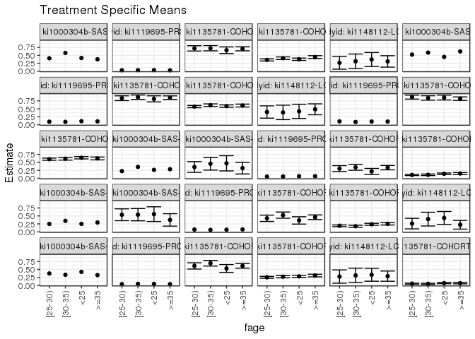

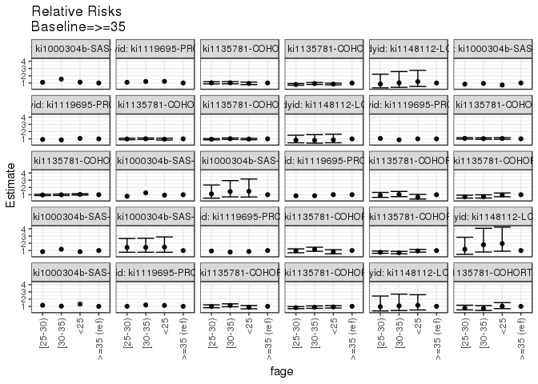

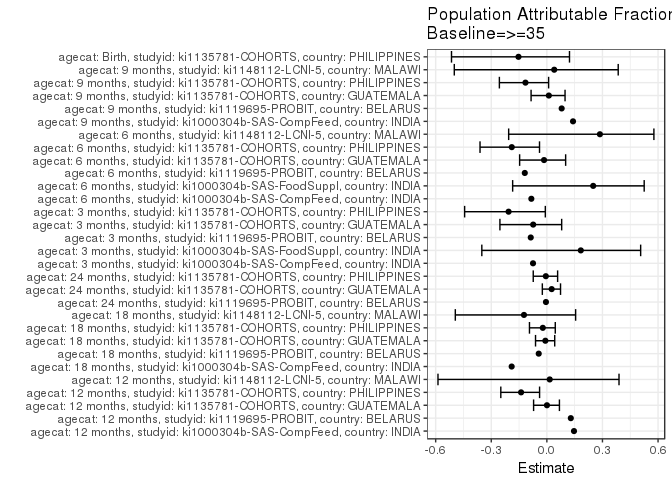

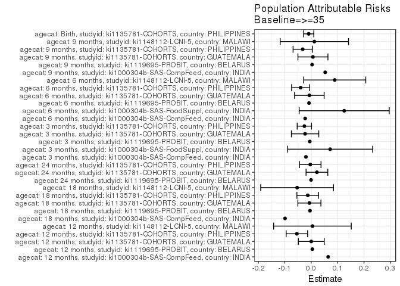

## Results Table

### Parameter: TSM

| agecat | studyid | country | intervention_level | baseline_level | estimate | ci_lower | ci_upper |
| --- | --- | --- | --- | --- | --- | --- | --- |
| Birth | ki1135781-COHORTS | PHILIPPINES | >=35 | NA | 0.0705009 | 0.0488862 | 0.0921156 |
| Birth | ki1135781-COHORTS | PHILIPPINES | <25 | NA | 0.0721393 | 0.0542530 | 0.0900256 |
| Birth | ki1135781-COHORTS | PHILIPPINES | [25-30) | NA | 0.0545073 | 0.0400993 | 0.0689154 |
| Birth | ki1135781-COHORTS | PHILIPPINES | [30-35) | NA | 0.0494590 | 0.0327490 | 0.0661691 |
| 3 months | ki1000304b-SAS-CompFeed | INDIA | >=35 | NA | 0.2857143 | NA | NA |
| 3 months | ki1000304b-SAS-CompFeed | INDIA | <25 | NA | 0.2647059 | NA | NA |
| 3 months | ki1000304b-SAS-CompFeed | INDIA | [25-30) | NA | 0.2239583 | NA | NA |
| 3 months | ki1000304b-SAS-CompFeed | INDIA | [30-35) | NA | 0.3580247 | NA | NA |
| 3 months | ki1000304b-SAS-FoodSuppl | INDIA | >=35 | NA | 0.3200000 | 0.1361948 | 0.5038052 |
| 3 months | ki1000304b-SAS-FoodSuppl | INDIA | <25 | NA | 0.4705882 | 0.2320867 | 0.7090898 |
| 3 months | ki1000304b-SAS-FoodSuppl | INDIA | [25-30) | NA | 0.3548387 | 0.1855347 | 0.5241427 |
| 3 months | ki1000304b-SAS-FoodSuppl | INDIA | [30-35) | NA | 0.4583333 | 0.2579556 | 0.6587111 |
| 3 months | ki1119695-PROBIT | BELARUS | >=35 | NA | 0.0662338 | NA | NA |
| 3 months | ki1119695-PROBIT | BELARUS | <25 | NA | 0.0669231 | NA | NA |
| 3 months | ki1119695-PROBIT | BELARUS | [25-30) | NA | 0.0562651 | NA | NA |
| 3 months | ki1119695-PROBIT | BELARUS | [30-35) | NA | 0.0567951 | NA | NA |
| 3 months | ki1135781-COHORTS | GUATEMALA | >=35 | NA | 0.3351351 | 0.2670399 | 0.4032304 |
| 3 months | ki1135781-COHORTS | GUATEMALA | <25 | NA | 0.2162162 | 0.1223191 | 0.3101133 |
| 3 months | ki1135781-COHORTS | GUATEMALA | [25-30) | NA | 0.3052632 | 0.2125564 | 0.3979699 |
| 3 months | ki1135781-COHORTS | GUATEMALA | [30-35) | NA | 0.3465347 | 0.2536274 | 0.4394419 |
| 3 months | ki1135781-COHORTS | PHILIPPINES | >=35 | NA | 0.1507634 | 0.1201210 | 0.1814058 |
| 3 months | ki1135781-COHORTS | PHILIPPINES | <25 | NA | 0.1420912 | 0.1170323 | 0.1671500 |
| 3 months | ki1135781-COHORTS | PHILIPPINES | [25-30) | NA | 0.1060268 | 0.0858644 | 0.1261892 |
| 3 months | ki1135781-COHORTS | PHILIPPINES | [30-35) | NA | 0.1098546 | 0.0852158 | 0.1344935 |
| 6 months | ki1000304b-SAS-CompFeed | INDIA | >=35 | NA | 0.2941176 | NA | NA |
| 6 months | ki1000304b-SAS-CompFeed | INDIA | <25 | NA | 0.2500000 | NA | NA |
| 6 months | ki1000304b-SAS-CompFeed | INDIA | [25-30) | NA | 0.2486772 | NA | NA |
| 6 months | ki1000304b-SAS-CompFeed | INDIA | [30-35) | NA | 0.3461538 | NA | NA |
| 6 months | ki1000304b-SAS-FoodSuppl | INDIA | >=35 | NA | 0.3750000 | 0.1802973 | 0.5697027 |
| 6 months | ki1000304b-SAS-FoodSuppl | INDIA | <25 | NA | 0.5555556 | 0.3247968 | 0.7863143 |

[output cut: 90 more lines]

### Parameter: E(Y)

| agecat | studyid | country | intervention_level | baseline_level | estimate | ci_lower | ci_upper |
| --- | --- | --- | --- | --- | --- | --- | --- |
| Birth | ki1135781-COHORTS | PHILIPPINES | NA | NA | 0.0611413 | 0.0524852 | 0.0697974 |
| 3 months | ki1000304b-SAS-CompFeed | INDIA | NA | NA | 0.2658537 | NA | NA |
| 3 months | ki1000304b-SAS-FoodSuppl | INDIA | NA | NA | 0.3917526 | 0.2941057 | 0.4893995 |
| 3 months | ki1119695-PROBIT | BELARUS | NA | NA | 0.0609347 | NA | NA |
| 3 months | ki1135781-COHORTS | GUATEMALA | NA | NA | 0.3120879 | 0.2694668 | 0.3547091 |
| 3 months | ki1135781-COHORTS | PHILIPPINES | NA | NA | 0.1249551 | 0.1126721 | 0.1372382 |
| 6 months | ki1000304b-SAS-CompFeed | INDIA | NA | NA | 0.2713936 | NA | NA |
| 6 months | ki1000304b-SAS-FoodSuppl | INDIA | NA | NA | 0.5000000 | 0.3994560 | 0.6005440 |
| 6 months | ki1119695-PROBIT | BELARUS | NA | NA | 0.0691107 | NA | NA |
| 6 months | ki1135781-COHORTS | GUATEMALA | NA | NA | 0.4516854 | 0.4053951 | 0.4979756 |
| 6 months | ki1135781-COHORTS | PHILIPPINES | NA | NA | 0.2118902 | 0.1962516 | 0.2275288 |
| 6 months | ki1148112-LCNI-5 | MALAWI | NA | NA | 0.3113208 | 0.2227550 | 0.3998865 |
| 9 months | ki1000304b-SAS-CompFeed | INDIA | NA | NA | 0.3756219 | NA | NA |
| 9 months | ki1119695-PROBIT | BELARUS | NA | NA | 0.0435929 | NA | NA |
| 9 months | ki1135781-COHORTS | GUATEMALA | NA | NA | 0.6206897 | 0.5750400 | 0.6663393 |
| 9 months | ki1135781-COHORTS | PHILIPPINES | NA | NA | 0.2762557 | 0.2591569 | 0.2933545 |
| 9 months | ki1148112-LCNI-5 | MALAWI | NA | NA | 0.3023256 | 0.2046913 | 0.3999599 |
| 12 months | ki1000304b-SAS-CompFeed | INDIA | NA | NA | 0.4393204 | NA | NA |
| 12 months | ki1119695-PROBIT | BELARUS | NA | NA | 0.0338664 | NA | NA |
| 12 months | ki1135781-COHORTS | GUATEMALA | NA | NA | 0.7033399 | 0.6636181 | 0.7430616 |
| 12 months | ki1135781-COHORTS | PHILIPPINES | NA | NA | 0.3889110 | 0.3698242 | 0.4079979 |
| 12 months | ki1148112-LCNI-5 | MALAWI | NA | NA | 0.3125000 | 0.2102894 | 0.4147106 |
| 18 months | ki1000304b-SAS-CompFeed | INDIA | NA | NA | 0.5216285 | NA | NA |
| 18 months | ki1119695-PROBIT | BELARUS | NA | NA | 0.1021798 | NA | NA |
| 18 months | ki1135781-COHORTS | GUATEMALA | NA | NA | 0.8441247 | 0.8092674 | 0.8789820 |
| 18 months | ki1135781-COHORTS | PHILIPPINES | NA | NA | 0.5902318 | 0.5706176 | 0.6098460 |
| 18 months | ki1148112-LCNI-5 | MALAWI | NA | NA | 0.4315789 | 0.3314524 | 0.5317055 |
| 24 months | ki1119695-PROBIT | BELARUS | NA | NA | 0.1006329 | NA | NA |
| 24 months | ki1135781-COHORTS | GUATEMALA | NA | NA | 0.8404040 | 0.8081087 | 0.8726994 |
| 24 months | ki1135781-COHORTS | PHILIPPINES | NA | NA | 0.6195698 | 0.6000239 | 0.6391157 |

### Parameter: RR

| agecat | studyid | country | intervention_level | baseline_level | estimate | ci_lower | ci_upper |
| --- | --- | --- | --- | --- | --- | --- | --- |
| Birth | ki1135781-COHORTS | PHILIPPINES | >=35 | >=35 | 1.0000000 | 1.0000000 | 1.0000000 |
| Birth | ki1135781-COHORTS | PHILIPPINES | <25 | >=35 | 1.0232391 | 0.6898198 | 1.5178141 |
| Birth | ki1135781-COHORTS | PHILIPPINES | [25-30) | >=35 | 0.7731436 | 0.5157693 | 1.1589502 |
| Birth | ki1135781-COHORTS | PHILIPPINES | [30-35) | >=35 | 0.7015375 | 0.4445433 | 1.1071021 |
| 3 months | ki1000304b-SAS-CompFeed | INDIA | >=35 | >=35 | 1.0000000 | NA | NA |
| 3 months | ki1000304b-SAS-CompFeed | INDIA | <25 | >=35 | 0.9264706 | NA | NA |
| 3 months | ki1000304b-SAS-CompFeed | INDIA | [25-30) | >=35 | 0.7838542 | NA | NA |
| 3 months | ki1000304b-SAS-CompFeed | INDIA | [30-35) | >=35 | 1.2530864 | NA | NA |
| 3 months | ki1000304b-SAS-FoodSuppl | INDIA | >=35 | >=35 | 1.0000000 | 1.0000000 | 1.0000000 |
| 3 months | ki1000304b-SAS-FoodSuppl | INDIA | <25 | >=35 | 1.4705882 | 0.6836166 | 3.1635128 |
| 3 months | ki1000304b-SAS-FoodSuppl | INDIA | [25-30) | >=35 | 1.1088710 | 0.5255190 | 2.3397723 |
| 3 months | ki1000304b-SAS-FoodSuppl | INDIA | [30-35) | >=35 | 1.4322917 | 0.6958869 | 2.9479781 |
| 3 months | ki1119695-PROBIT | BELARUS | >=35 | >=35 | 1.0000000 | NA | NA |
| 3 months | ki1119695-PROBIT | BELARUS | <25 | >=35 | 1.0104072 | NA | NA |
| 3 months | ki1119695-PROBIT | BELARUS | [25-30) | >=35 | 0.8494927 | NA | NA |
| 3 months | ki1119695-PROBIT | BELARUS | [30-35) | >=35 | 0.8574951 | NA | NA |
| 3 months | ki1135781-COHORTS | GUATEMALA | >=35 | >=35 | 1.0000000 | 1.0000000 | 1.0000000 |
| 3 months | ki1135781-COHORTS | GUATEMALA | <25 | >=35 | 0.6451613 | 0.3994319 | 1.0420628 |
| 3 months | ki1135781-COHORTS | GUATEMALA | [25-30) | >=35 | 0.9108659 | 0.6320686 | 1.3126370 |
| 3 months | ki1135781-COHORTS | GUATEMALA | [30-35) | >=35 | 1.0340147 | 0.7386354 | 1.4475157 |
| 3 months | ki1135781-COHORTS | PHILIPPINES | >=35 | >=35 | 1.0000000 | 1.0000000 | 1.0000000 |
| 3 months | ki1135781-COHORTS | PHILIPPINES | <25 | >=35 | 0.9424780 | 0.7201202 | 1.2334952 |
| 3 months | ki1135781-COHORTS | PHILIPPINES | [25-30) | >=35 | 0.7032663 | 0.5324015 | 0.9289671 |
| 3 months | ki1135781-COHORTS | PHILIPPINES | [30-35) | >=35 | 0.7286559 | 0.5383578 | 0.9862202 |
| 6 months | ki1000304b-SAS-CompFeed | INDIA | >=35 | >=35 | 1.0000000 | NA | NA |
| 6 months | ki1000304b-SAS-CompFeed | INDIA | <25 | >=35 | 0.8500000 | NA | NA |
| 6 months | ki1000304b-SAS-CompFeed | INDIA | [25-30) | >=35 | 0.8455026 | NA | NA |
| 6 months | ki1000304b-SAS-CompFeed | INDIA | [30-35) | >=35 | 1.1769231 | NA | NA |
| 6 months | ki1000304b-SAS-FoodSuppl | INDIA | >=35 | >=35 | 1.0000000 | 1.0000000 | 1.0000000 |
| 6 months | ki1000304b-SAS-FoodSuppl | INDIA | <25 | >=35 | 1.4814815 | 0.7619556 | 2.8804662 |

[output cut: 90 more lines]

### Parameter: PAR

| agecat | studyid | country | intervention_level | baseline_level | estimate | ci_lower | ci_upper |
| --- | --- | --- | --- | --- | --- | --- | --- |
| Birth | ki1135781-COHORTS | PHILIPPINES | >=35 | NA | -0.0093596 | -0.0286223 | 0.0099031 |
| 3 months | ki1000304b-SAS-CompFeed | INDIA | >=35 | NA | -0.0198606 | NA | NA |
| 3 months | ki1000304b-SAS-FoodSuppl | INDIA | >=35 | NA | 0.0717526 | -0.0891967 | 0.2327018 |
| 3 months | ki1119695-PROBIT | BELARUS | >=35 | NA | -0.0052991 | NA | NA |
| 3 months | ki1135781-COHORTS | GUATEMALA | >=35 | NA | -0.0230472 | -0.0748430 | 0.0287486 |
| 3 months | ki1135781-COHORTS | PHILIPPINES | >=35 | NA | -0.0258082 | -0.0529467 | 0.0013303 |
| 6 months | ki1000304b-SAS-CompFeed | INDIA | >=35 | NA | -0.0227240 | NA | NA |
| 6 months | ki1000304b-SAS-FoodSuppl | INDIA | >=35 | NA | 0.1250000 | -0.0454807 | 0.2954807 |
| 6 months | ki1119695-PROBIT | BELARUS | >=35 | NA | -0.0082299 | NA | NA |
| 6 months | ki1135781-COHORTS | GUATEMALA | >=35 | NA | -0.0068781 | -0.0628052 | 0.0490490 |
| 6 months | ki1135781-COHORTS | PHILIPPINES | >=35 | NA | -0.0401259 | -0.0740806 | -0.0061712 |
| 6 months | ki1148112-LCNI-5 | MALAWI | >=35 | NA | 0.0890985 | -0.0284429 | 0.2066400 |
| 9 months | ki1000304b-SAS-CompFeed | INDIA | >=35 | NA | 0.0530412 | NA | NA |
| 9 months | ki1119695-PROBIT | BELARUS | >=35 | NA | 0.0034823 | NA | NA |
| 9 months | ki1135781-COHORTS | GUATEMALA | >=35 | NA | 0.0066546 | -0.0501324 | 0.0634415 |
| 9 months | ki1135781-COHORTS | PHILIPPINES | >=35 | NA | -0.0319076 | -0.0685259 | 0.0047108 |
| 9 months | ki1148112-LCNI-5 | MALAWI | >=35 | NA | 0.0120030 | -0.1173854 | 0.1413914 |
| 12 months | ki1000304b-SAS-CompFeed | INDIA | >=35 | NA | 0.0643204 | NA | NA |
| 12 months | ki1119695-PROBIT | BELARUS | >=35 | NA | 0.0043758 | NA | NA |
| 12 months | ki1135781-COHORTS | GUATEMALA | >=35 | NA | 0.0003696 | -0.0486055 | 0.0493447 |
| 12 months | ki1135781-COHORTS | PHILIPPINES | >=35 | NA | -0.0540997 | -0.0946841 | -0.0135153 |
| 12 months | ki1148112-LCNI-5 | MALAWI | >=35 | NA | 0.0048077 | -0.1421685 | 0.1517839 |
| 18 months | ki1000304b-SAS-CompFeed | INDIA | >=35 | NA | -0.0990612 | NA | NA |
| 18 months | ki1119695-PROBIT | BELARUS | >=35 | NA | -0.0044868 | NA | NA |
| 18 months | ki1135781-COHORTS | GUATEMALA | >=35 | NA | -0.0068070 | -0.0504669 | 0.0368530 |
| 18 months | ki1135781-COHORTS | PHILIPPINES | >=35 | NA | -0.0129072 | -0.0539650 | 0.0281505 |
| 18 months | ki1148112-LCNI-5 | MALAWI | >=35 | NA | -0.0532695 | -0.1910932 | 0.0845541 |
| 24 months | ki1119695-PROBIT | BELARUS | >=35 | NA | -0.0004907 | NA | NA |
| 24 months | ki1135781-COHORTS | GUATEMALA | >=35 | NA | 0.0217512 | -0.0194191 | 0.0629214 |
| 24 months | ki1135781-COHORTS | PHILIPPINES | >=35 | NA | -0.0034550 | -0.0441755 | 0.0372654 |

### Parameter: PAF

| agecat | studyid | country | intervention_level | baseline_level | estimate | ci_lower | ci_upper |
| --- | --- | --- | --- | --- | --- | --- | --- |
| Birth | ki1135781-COHORTS | PHILIPPINES | >=35 | NA | -0.1530818 | -0.5145436 | 0.1221133 |
| 3 months | ki1000304b-SAS-CompFeed | INDIA | >=35 | NA | -0.0747051 | NA | NA |
| 3 months | ki1000304b-SAS-FoodSuppl | INDIA | >=35 | NA | 0.1831579 | -0.3509648 | 0.5061078 |
| 3 months | ki1119695-PROBIT | BELARUS | >=35 | NA | -0.0869635 | NA | NA |
| 3 months | ki1135781-COHORTS | GUATEMALA | >=35 | NA | -0.0738485 | -0.2533170 | 0.0799211 |
| 3 months | ki1135781-COHORTS | PHILIPPINES | >=35 | NA | -0.2065401 | -0.4437558 | -0.0083000 |
| 6 months | ki1000304b-SAS-CompFeed | INDIA | >=35 | NA | -0.0837308 | NA | NA |
| 6 months | ki1000304b-SAS-FoodSuppl | INDIA | >=35 | NA | 0.2500000 | -0.1845905 | 0.5251524 |
| 6 months | ki1119695-PROBIT | BELARUS | >=35 | NA | -0.1190831 | NA | NA |
| 6 months | ki1135781-COHORTS | GUATEMALA | >=35 | NA | -0.0152277 | -0.1469210 | 0.1013441 |
| 6 months | ki1135781-COHORTS | PHILIPPINES | >=35 | NA | -0.1893711 | -0.3606631 | -0.0396428 |
| 6 months | ki1148112-LCNI-5 | MALAWI | >=35 | NA | 0.2861953 | -0.2061228 | 0.5775578 |
| 9 months | ki1000304b-SAS-CompFeed | INDIA | >=35 | NA | 0.1412091 | NA | NA |
| 9 months | ki1119695-PROBIT | BELARUS | >=35 | NA | 0.0798821 | NA | NA |
| 9 months | ki1135781-COHORTS | GUATEMALA | >=35 | NA | 0.0107212 | -0.0851413 | 0.0981152 |
| 9 months | ki1135781-COHORTS | PHILIPPINES | >=35 | NA | -0.1155001 | -0.2562170 | 0.0094542 |
| 9 months | ki1148112-LCNI-5 | MALAWI | >=35 | NA | 0.0397022 | -0.4994909 | 0.3850101 |
| 12 months | ki1000304b-SAS-CompFeed | INDIA | >=35 | NA | 0.1464088 | NA | NA |
| 12 months | ki1119695-PROBIT | BELARUS | >=35 | NA | 0.1292076 | NA | NA |
| 12 months | ki1135781-COHORTS | GUATEMALA | >=35 | NA | 0.0005255 | -0.0715897 | 0.0677875 |
| 12 months | ki1135781-COHORTS | PHILIPPINES | >=35 | NA | -0.1391056 | -0.2484990 | -0.0392972 |
| 12 months | ki1148112-LCNI-5 | MALAWI | >=35 | NA | 0.0153846 | -0.5875082 | 0.3893150 |
| 18 months | ki1000304b-SAS-CompFeed | INDIA | >=35 | NA | -0.1899075 | NA | NA |
| 18 months | ki1119695-PROBIT | BELARUS | >=35 | NA | -0.0439111 | NA | NA |
| 18 months | ki1135781-COHORTS | GUATEMALA | >=35 | NA | -0.0080639 | -0.0611472 | 0.0423638 |
| 18 months | ki1135781-COHORTS | PHILIPPINES | >=35 | NA | -0.0218681 | -0.0938604 | 0.0453861 |
| 18 months | ki1148112-LCNI-5 | MALAWI | >=35 | NA | -0.1234294 | -0.4939937 | 0.1552215 |
| 24 months | ki1119695-PROBIT | BELARUS | >=35 | NA | -0.0048760 | NA | NA |
| 24 months | ki1135781-COHORTS | GUATEMALA | >=35 | NA | 0.0258818 | -0.0244578 | 0.0737478 |
| 24 months | ki1135781-COHORTS | PHILIPPINES | >=35 | NA | -0.0055765 | -0.0734962 | 0.0580460 |